# 编码与解码

## 编码的数据与解码的数据要使用相同的编码规则,否则会造成乱码

```python
a = '你好啊'.encode('gbk')
a
```

```
b'\xc4\xe3\xba\xc3\xb0\xa1'
```

```python
a.decode('gbk')
```

```
'你好啊'
```

# 文件的读取与写入

`open()` 函数  
`close()`函数

### `with open() as filename:` 语句打开文件

- 参数： 文件目录， 读取模式
- 关键字参数：encoding

| 模式名称 | 功能 | 文件不存在 | 文件是否有内容 |
| --- | --- | --- | --- |
| `r` | 读取 | 报错 | 读取 |
| `r+` | 读写模式 | 报错 | 读取文件内容， 修改时覆盖 |
| `rb` | 读取文件的二进制内容 | 报错 | 读取文件的二进制内容 |
| `w` | 只写模式 | 创建新的文件 | 覆盖 |
| `w+` | 读写模式 | 创建新的文件 | 覆盖 |
| `wb` | 写入二进制文件 | 创建新的文件 | 覆盖 |
| `a` | 添加模式 | 创建新的文件 | 继续文件原有的内容添加 |

# 读

- 读模式下确保文件存在, 若**文件路径不存在就会报错**

```python
# 当前目录下并没有test.txt这个文件
with open('test.txt', 'r') as filename:
    print(filename)
```

```
---------------------------------------------------------------------------
FileNotFoundError                         Traceback (most recent call last)
<ipython-input-1-5754e93b8369> in <module>
      1 # 当前目录下并没有test.txt这个文件
----> 2 with open('test.txt', 'r') as filename:
      3     print(filename)

FileNotFoundError: [Errno 2] No such file or directory: 'test.txt'
```

- 用读模式打开一个文本文档文件,输出得到一个**文件对象**

```python
with open('happy.txt', 'r') as filename:
    print(filename)
```

```
<_io.TextIOWrapper name='happy.txt' mode='r' encoding='cp936'>
```

- **用电脑打开文档的内容**

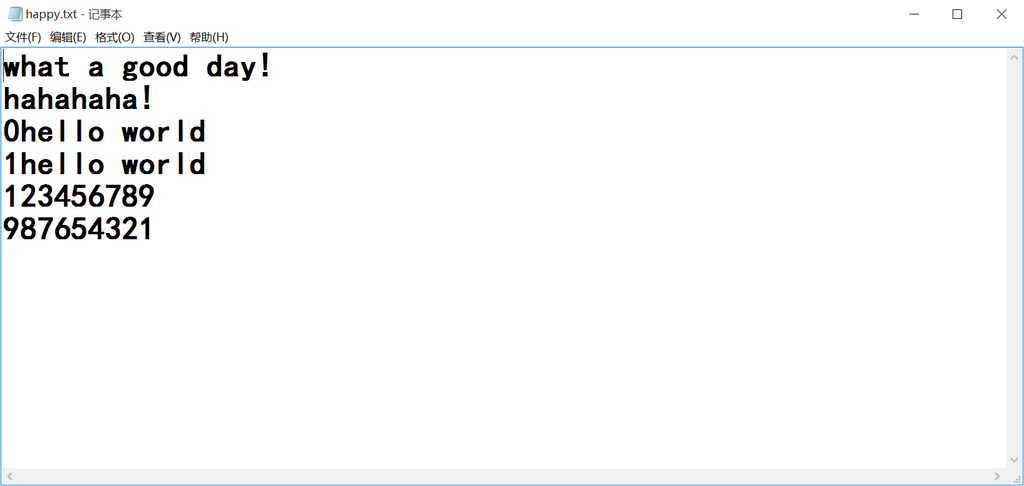

**`read()`方法： 读取文件的文本内容，以字符串( * )的形式返回**

```python
with open('happy.txt', 'r') as filename:
    msg = filename.read()
    print(msg)
```

```
what a good day!
hahahaha!
0hello world
1hello world
123456789
987654321
```

- **可以在`read()`方法里传入要读取的字节数**

```python
with open('happy.txt', 'r') as filename:
    msg = filename.read(4)
    print(msg)
    # 每次读取会移动光标的位置, 下次读取会从光标后读取
    msg2 = filename.read(5)
    print(msg2)
```

```
what
 a go
```

- 利用`readline()`读取文件的**一行信息**

```python
with open('happy.txt', 'r') as filename:
    msg = filename.readline()
    print(msg)
    # 每次读取会移动光标的位置, 下次读取会从光标后读取
    msg2 = filename.readline()
    print(msg2)
```

```
what a good day!

hahahaha!
```

- 直接**用for循环遍历文件,会得到每行的内容, 并且会自动为每行加入换行符**

```python
with open('happy.txt', 'r') as filename:
    for line in filename:
        print(line)
```

```
what a good day!

hahahaha!

0hello world

1hello world

123456789

987654321
```

```python
with open('happy.txt', 'r') as filename:
    for line in filename:
        # strObj.strip() 方法去掉字符串前后的空白符
        print(line.strip())
```

```
what a good day!
hahahaha!
0hello world
1hello world
123456789
987654321
```

`readlines()`方法,把每行内容存储在列表里

```python
with open('happy.txt', 'r') as filename:
    lines = filename.readlines()
```

```python
lines
```

[output not shown]

- `rb` 模式下读取的是**文件的二进制内容**

```python
with open('happy.txt', 'rb') as filename:
    data = filename.read()
    print(data)
```

```
b'what a good day! \r\nhahahaha! \r\n0hello world\r\n1hello world\r\n123456789\r\n987654321'
```

( * )如上, 字符串引号前若标有b,则代表这是**一段编码后的数据**

```python
# data 变量非字符串类型
type(data)
```

```
bytes
```

# 写

**`write()` 方法， 为文件对象写入内容**

若要写入的文件**不存在, 则在该路径下创建一个同名空白文件**

尝试打开一个不存在的文件未报错

```python
with open('这个真没有.txt', 'w') as file:
    print(file)
```

```
<_io.TextIOWrapper name='这个真没有.txt' mode='w' encoding='cp936'>
```

- **`write()`方法, 给文件写入内容**, 参数为要写入的内容

**给空白的文件写入内容**

```python
with open('这个真没有.txt', 'w') as file:
    file.write('这是我写入的一句话')
    # 多次写入不会换行, 直接在当前光标后写入内容
    file.write('这是我写入的第二句话')
```

*写入后效果如图:*

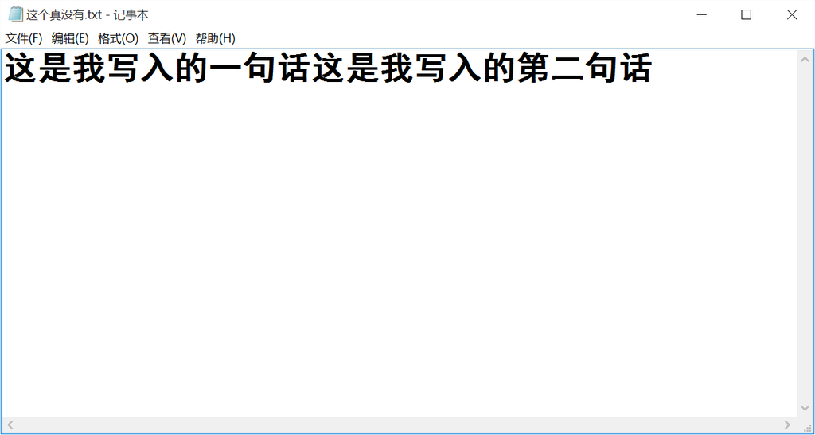

- **重新打开该文件, 写入新的内容**
- **用写入模式为已存在的文件写入新的内容, 新的内容会覆盖原有内容**

```python
with open('这个真没有.txt', 'w') as file:
    # 新写入的内容会覆盖原有内容
    file.write('这是我写的第三句话!')
```

*如图*

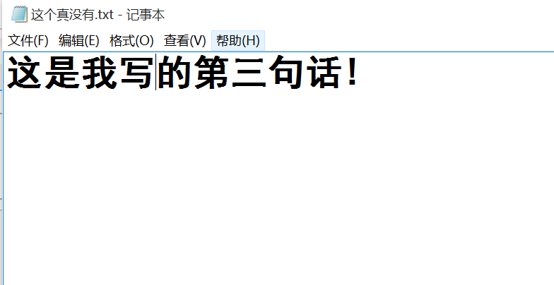

**所以如果用写入模式想要一次性把所有内容写到文件里, 需要保证在此期间不要关闭文件**

```python
with open('这个真没有.txt', 'w') as file:
    # 需要自己为内容添加换行符
    file.write('这是我写入的第一句话\n')
    file.write('这是我写入的第二句话\n')
    file.write('这是我写入的第三句话\n')
    file.write('这是我写入的第四句话\n')
    file.write('这是我写入的第五句话\n')
```

*如图*

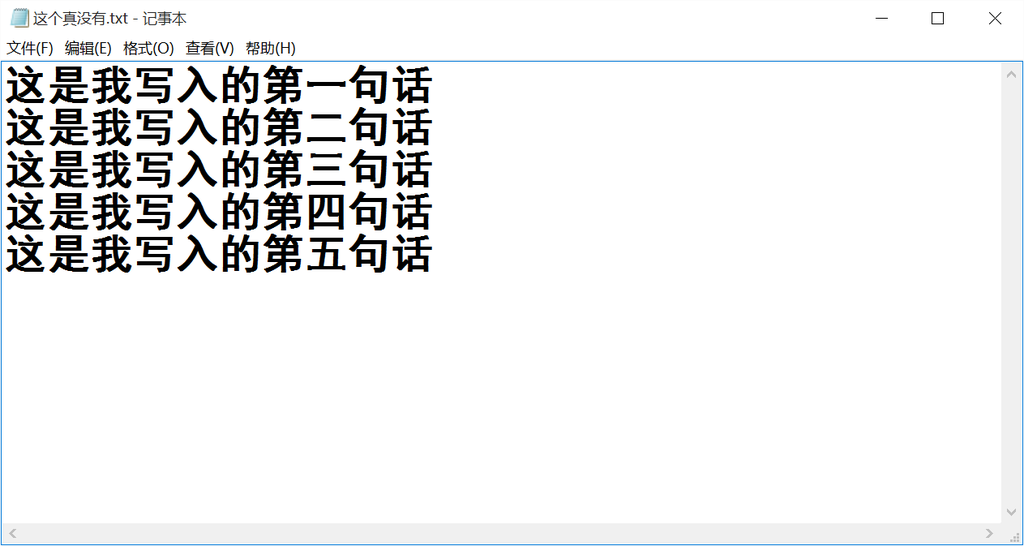

- `writelines()` 方法,能够把**列表中**的内容,批量写入到文档中

```python
todo_list = [
    '1. 做运动',
    '2. 背英语单词',
    '3. 做作业']
with open('计划表.txt', 'w') as file:
    file.writelines(todo_list)
```

*如图*

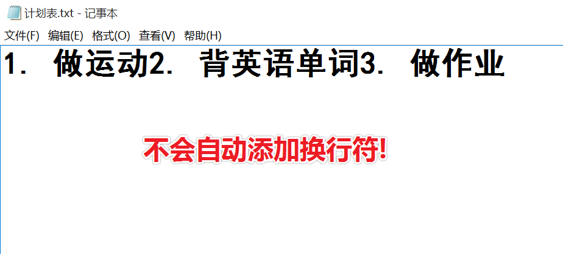

```python
# 加入换行符
todo_list = [
    '1. 做运动\n',
    '2. 背英语单词\n',
    '3. 做作业\n']
with open('计划表.txt', 'w') as file:
    file.writelines(todo_list)
```

*如图*

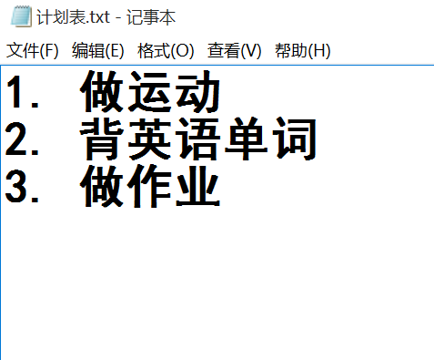

# 添加

> `a模式(append)`

添加模式的用法与写模式**用法基本相同**, 区别在于当打开文件以存在内容时,  
**新写入的内容不会覆盖原有内容**, 而是**添加在原有内容之后**  
*(打开文件时,光标处于文件的内容的最后)*

```python
with open('这个真没有.txt', 'a') as file:
        file.write('这是新添加的一语句\n')
```

*如图*

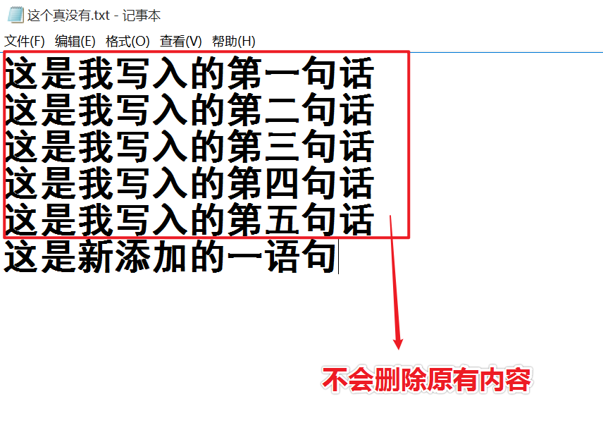

# 非读取模式下,不能使用`read`读取文件内容

```python
with open('这个真没有.txt', 'a') as file:
        msg = file.read()
        print(msg)
```

```
---------------------------------------------------------------------------
UnsupportedOperation                      Traceback (most recent call last)
<ipython-input-19-9aa526aeaf08> in <module>
      1 with open('这个真没有.txt', 'a') as file:
----> 2         msg = file.read()
      3         print(msg)

UnsupportedOperation: not readable
```

```python
with open('这个真没有.txt', 'w') as file:
        msg = file.read()
        print(msg)
```

```
---------------------------------------------------------------------------
UnsupportedOperation                      Traceback (most recent call last)
<ipython-input-20-d1645d6b833b> in <module>
      1 with open('这个真没有.txt', 'w') as file:
----> 2         msg = file.read()
      3         print(msg)

UnsupportedOperation: not readable
```

**尝试在非读模式下读取内容会报错**

# 作业:

- 参考上面的代码, 完成一个程序: 写日记程序
  - 需要实现的功能, 把输入的文字或者日记内容,写入到一个文件夹中,并按照日期保存  
    *(input, 文件读取写入, 变量, datetime模块)*

## 尝试把内容写入到`csv`表格中

[figure not shown]

## 小六的个人资料

| 名称 | 年龄 | 颜色 | 爱好 |
| --- | --- | --- | --- |
| 小六 | 12 | 红色 | 唱歌 |

```python
with open('小六的个人资料.csv', 'a') as f:
    f.write('名称,年龄,颜色,爱好,\n')
    f.write('小六,12,红色,唱歌,\n')
```

[figure not shown]

**直接用wirte为csv文件添加数据需要保证数据必须为字符串且数据间以逗号分开,容易出错** **如果想快速的把数据写入为csv表格, 可以利用`csv模块`**

## 处理csv文件的csv模块

csv模块可以为我们提供**csv的阅读器和csv的编辑器**

- 阅读器: 读取文件内容的工具, 比如看小说需要用小说阅读器(kindle,ireader等)
- 编辑器: 编辑文件内容时使用的工具, 比如写word文档需要用wps文档编辑器

[figure not shown]

### 导入csv模块

```python
import csv
```

# 读

比如要利用csv模块读取`student_scores.csv`这个文件里的内容

`csv.reader(读取的表格文件)` 用csv阅读器读取一个csv表格

```python
with open('student_scores.csv', 'r') as f:
    # 创建一个csv阅读器
    csv_reader = csv.reader(f)
#     print(csv_reader)
    for line in csv_reader:
        print(line)
```

[output not shown]

# 写

`csv.writer(csv_file)` 创建csv编辑器, 对指定的csv文件进行编辑(修改,写入内容等)

`writerObj.writerow(列表)` 为csv文件添加一行数据  
把一个列表的所有内容写到一行中,并以逗号隔开

```python
with open('小六的个人资料_模块编辑版.csv', 'a') as f:
    # 创建csv编辑器
    csv_wri = csv.writer(f)
    # writerow 按行加入内容, 把一个列表中的元素当做一行数据加入
    csv_wri.writerow(['名字', '年龄', '颜色','爱好'])
    csv_wri.writerow(['小六', 12, '红色', '唱歌'])
```

[figure not shown]

```python
#                                               取消新加行时添加的换行符, 设置文件内容的编码
with open('小六的个人资料_模块编辑版.csv', 'a', newline = '', encoding = 'utf-8') as f:
    # 创建csv编辑器
    csv_wri = csv.writer(f)
    # writerow 按行加入内容, 把一个列表中的元素当做一行数据加入
    csv_wri.writerow(['小七', 15, '蓝色', '睡觉'])
    csv_wri.writerow(['小八', 19, '绿色', '跳舞'])
```

[figure not shown]

# 作业:

- 把微博爬取的关注数据写入到一个表格中
- 练习:csv模块